# StatQuest_1_R-squared explained

Delmotte Jean

4 juillet 2018

from : https://www.youtube.com/watch?v=2AQKmw14mHM

# Ce que l’on sait sur le Coefficient de corrélation, aussi appelé R et R²

## R

- Plus le coefficient de corrélation est proche de 1 ou de -1, plus cela indique que deux variables quantitatives (par exemple la taille, le poids …) sont lié.

## R²

- Pourquoi on s’intéresse à R² vue qu’on a déjà R ?
- R² est similaire et fonctionne de la même faàon que R
- Sont interpretation est beaucoup plus simple :
- Ce n’est pas évident mais R=0.7 est 2 fois mieux que R=0.5 (ou les 2 R sont les R classique)
- Toutefois, R²=0.7 est 1.4 fois mieux que R²=0.5
- Enfin R² est beaucoup plus intuitif à calculer

## Analyse d’un dataset :

Création d’un dataset nommé “donnes” :

```r
donnees <- data.frame(taille=c(185,178,175,171,172), poids=c(82,69,70,65,68), souris=c("1","2","3","4","5"))
donnees
```

```
##   taille poids souris
## 1    185    82      1
## 2    178    69      2
## 3    175    70      3
## 4    171    65      4
## 5    172    68      5
```

Regardont un peut ces données : I.1. Quelle est le poids des différentes souris

```r
plot(donnees$souris, donnees$poids) # x, y
mean(donnees$poids)
```

```
## [1] 70.8
```

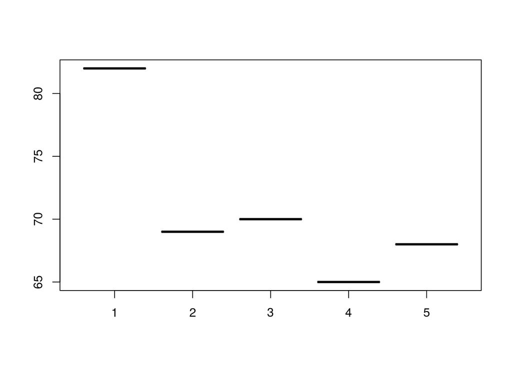

```r
abline(v=mean(donnees$poids), col= "red")
```

Remarque : - la fonction “mean()” permet de calculer la moyenne - la fonction “abline()” permet de mettre une moyenne sur le graphe

I.2. On peux calculer quelle est la variation entre ces data en avec : - La somme de chacun des poids pour une souris “i”- sa moyenne, le tout au carré - soit : Varation des données = Sum ( poids pour une souris “i” - moyenne du poids de toutes les souris)²

- soit :

$\sum_{i=1}^{5} (Poids_i - \bar{p})²$

```r
# - soit, en R :
var_poids = sum( sapply( (donnees$poids - mean(donnees$poids) ), function(x) x^2) )
var_poids
```

```
## [1] 170.8
```

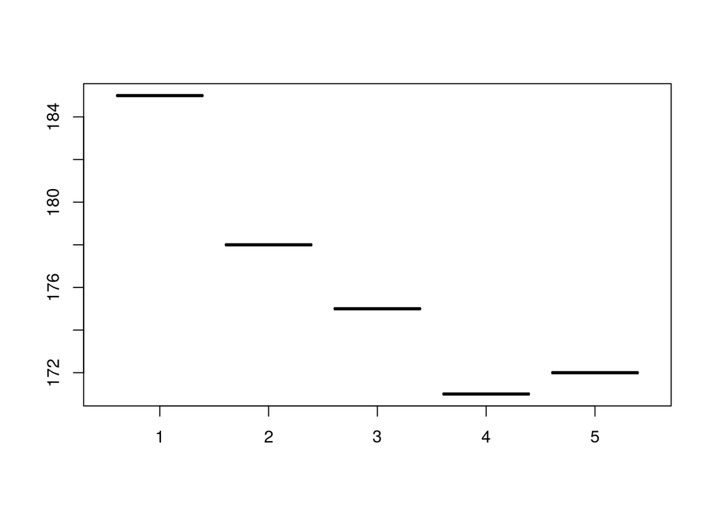

```r
plot(donnees$souris, donnees$taille)
abline(v=mean(donnees$poids), col= "green")
```

```r
var_taille = sum( sapply( (donnees$taille - mean(donnees$taille) ), function(x) x^2) )
var_taille
```

```
## [1] 126.8
```

3. On regarde maintenant pour les deux paramètres :
- Auparavant on a regardé séparément, et on ordonnée avec le numéro de la souris
- Maintenant on va réordonnée la taille avec le poids :

*Remarque* : Cette fois on va regardé avec l’excellent package ggplot2 mais la fonction plot aurait pu le faire

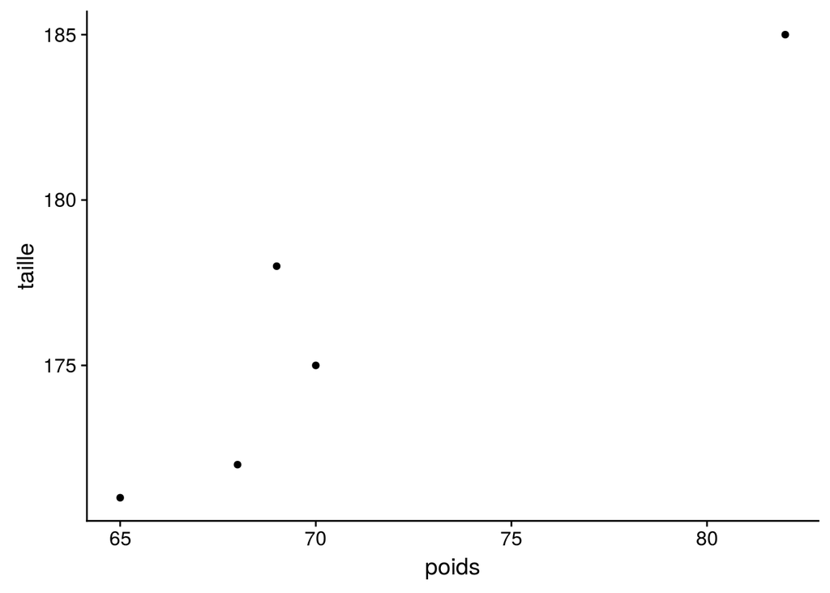

```r
courbe <- ggplot(data = donnees,
aes(x=poids,
    y=taille
    ), width=1) +
  geom_point()
plot(courbe)
```

- Tout ce qui a été fait ici c’est donc de réordonnée les données sur l’axe x ; la moyenne et la variation des deux axes est donc **exactement la même** que calculé précédemment !
- La distance entre les points et la ligne représentant la moyenne n’a pas **changé** (seul l’ordre à changé)

**Question 1 :**

Sachant ce que l’on sait sur la taille d’une souris, la moyenne du poids est il **le meilleur moyen de prédire** le poids d’une souris ?

**NON** on peut faire bien mieux, il suffit juste de tracé la ligne qui “fit” le mieux les données

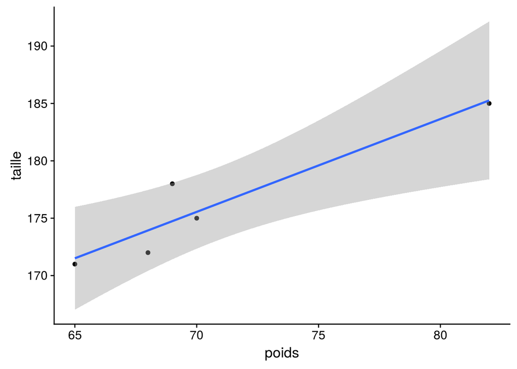

```r
courbe <- ggplot(data = donnees,
aes(x=poids,
    y=taille
    ), width=1) +
  geom_point() +
  geom_smooth(method="lm")
plot(courbe)
```

Maintenant on peut prédire le poids grace a cette **droite**. Si j’ai une souris qui est grosse, je peux regarder ma ligne et faire une bonne prédiction sur le poids.

*Remarque* : On appel cette droite, la droite de régression linéaire

```r
reg<-lm(poids ~ taille, data = donnees)
reg
```

```
##
## Call:
## lm(formula = poids ~ taille, data = donnees)
##
## Coefficients:
## (Intercept)       taille
##     -121.24         1.09
```

**Question 2 :** - Est-ce que cette ligne “fit” les données mieux que la moyenne ? Si oui combien de fois mieux ? - Comment quantifié cette différence alors ?

*réponse* : R²

Pour le calculer il suffit de faire :

R² = ( var(mean(poids)) - var(ligne) ) / var(mean(taille)) avec var le coefficient de variation

$\frac{\sum_{i=1}^{5} (Poids_i - \bar{p})² - \sum_{i=1}^{5} (Poids_i - \bar{p})² }{\sum_{i=1}^{5} (taille_i - \bar{p})}$

```r
var_poids = sum( sapply( (donnees$poids - mean(donnees$poids) ), function(x) x^2) )
var_poids
```

```
## [1] 170.8
```

```r
cor(donnees$poids, donnees$taille)
```

```
## [1] 0.9390841
```